# Project: Investigate a Dataset (Show and No Show of Patients for Medical Appointments)

### Research Question 10 (Does Sending SMS to Patients affects the Show status!)

##### Go Home 🏠

We will explore the data for the Show Patients at Scheduled Day based on SMS Message Received using both cleaned dataframe and filtered dataframe by unique Patient in order to compare both.

```
No     75035
Yes    35481
Name: SMS_received, dtype: int64
```

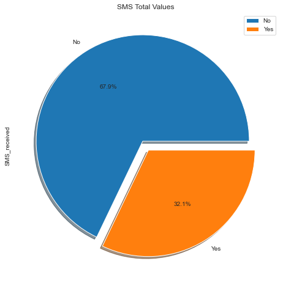

```
Show     SMS_received
No-Show  No              12527
         Yes              9784
Show     No              62508
         Yes             25697
dtype: int64
```

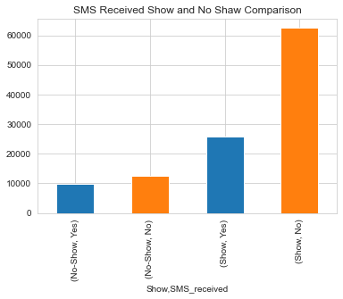

```
0    83.305124
1    16.694876
2    72.424678
3    27.575322
Name: Percent, dtype: float64
No     41902
Yes    20394
Name: SMS_received, dtype: int64
```

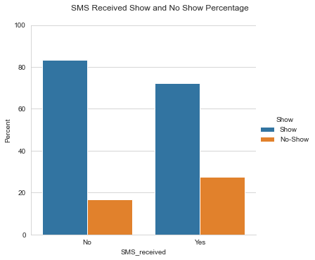

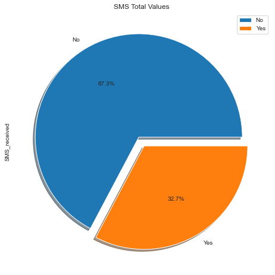

```
Show     SMS_received
No-Show  No               6700
         Yes              5491
Show     No              35202
         Yes             14903
dtype: int64
```

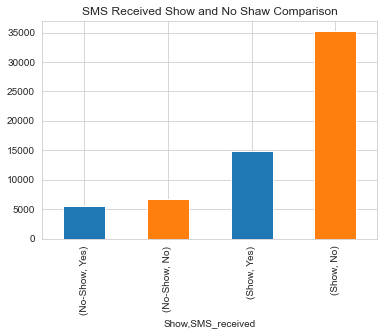

```
0    84.010310
1    15.989690
2    73.075414
3    26.924586
Name: Percent, dtype: float64
```

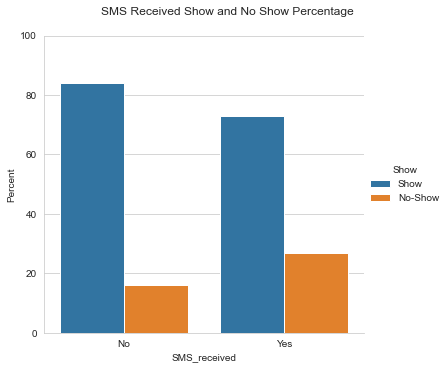

```python
plot_col(df_c, 'SMS_received', 'SMS Total Values', 'SMS Received Show and No Shaw Comparison', 'SMS Received Show and No Show Percentage');
plot_col(df_c_patient, 'SMS_received', 'SMS Total Values', 'SMS Received Show and No Shaw Comparison', 'SMS Received Show and No Show Percentage');
```

> From Above:
> - A shocking result that Patients received SMS have a higher percenatge of No Show 🤔 .

### Research Question 11 (Average Age of Show and No Show!)

##### Go Home 🏠

in this section we will use the dataframe filtered by the Patient ID is the Age of Each patient is unique

```
Show     Age
Show     0      1680
         1      1169
         2       921
         3       799
         56      763
                ...
No-Show  97        2
Show     102       2
No-Show  98        1
Show     99        1
No-Show  96        1
Length: 201, dtype: int64
```

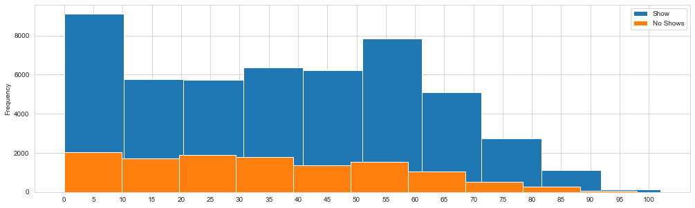

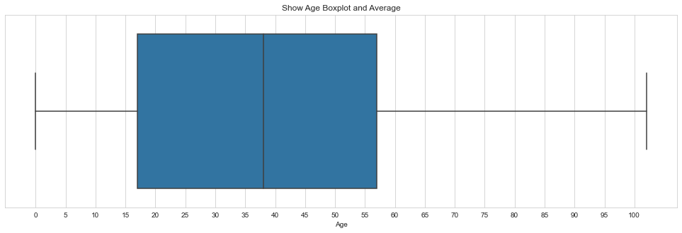

```
Average Age of No Show =37.39982037720787
```

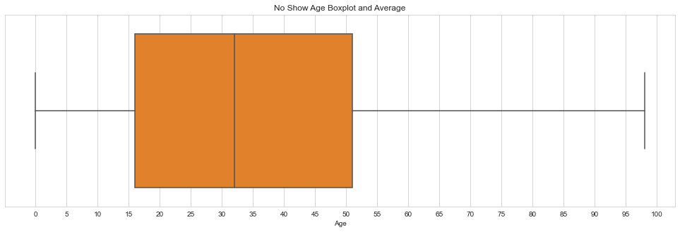

```
Average Age of No Show =33.83897957509638
```

```python
print(df_c_patient.groupby(['Show', 'Age']).size().sort_values(ascending=False))

Shows = (df_c_patient.Show == 'Show')
No_Shows = (df_c_patient.Show == 'No-Show')

df_c_patient[Shows].Age.plot.hist(figsize=(17,5))
df_c_patient[No_Shows].Age.plot.hist()
plt.xticks(np.arange(0, 105, 5.0))
plt.legend(['Show', 'No Shows'])
plt.show()

fig, ax = pyplot.subplots(figsize=(17,5))
plt.xticks(np.arange(0, 105, 5.0))
sns.boxplot(x=df_c_patient[Shows].Age)
plt.title('Show Age Boxplot and Average')
plt.show()
print('Average Age of No Show ={}'.format(df_c_patient[Shows].Age.mean()))

fig, ax = pyplot.subplots(figsize=(17,5))
plt.xticks(np.arange(0, 105, 5.0))
sns.boxplot(x=df_c_patient[No_Shows].Age, color='tab:orange')
plt.title('No Show Age Boxplot and Average')
plt.show()
print('Average Age of No Show ={}'.format(df_c_patient[No_Shows].Age.mean()))
```

> From above:
> - Average Age of Patients whom show at Apointment is 37.5 Years
> - Average Age of Patients whom No show at Apointment is 33.5 Years

## Conclusions

From above Data investigation, we have tried to find out WHY we have Many Patients Not Showing at their Appointments and What factors make Patient No Show and what is the recommendation for that. There has been many data at provided dataset and we have selected some important factors but of course more data can be retreived by more investigation. From our answers to the Research Questions we have concluded the below findings:

- Percentage of Patients not showing at their Scheduled Day is 20% which is considered high and need to be rectified
- Saturday is the highest Patients Show percenatage at their appointments and less No Show and that's because of the Holiday
- Tuesday has the Highest number of Patients applying for appointments, highest Number of Shows and highest number of no show. So hospital could limit the number of appointments at tuesday and move to Saturday
- The Waiting days have a big impact to Patients to Show at their appointment. the less waiting days, the heighest number and percent of patients Showing at their appointments. So Most important to schedule close appointments as much as possible
- Patients with Scholar Ship doesn't apppear to be more obligated to their appointments, and that's need more interest by giving them more options and facilities encouraging them to respect their appointments.
- The Patients Diabetes only has the Lowest Show Frquency than those with hypertension. So we could do compaign to Patients have diabetes to increase their awarness
- The Patients with Handicap Status 1 have the heighst Show Percentage then Status 2 comes next. for status with Handicap 3 and 4 has lowest percentage, seems they need more help for transportation for hospital. So we need to find some facilities help Handicap level 3 and 4 to help them Show at their appointments
- A shocking result that Patients received SMS have a higher percenatge of No Show. need to evaluate and check how the SMS text shows, when it is been sent and what we can do to improve SMS
- Percentage of Alcoholic Patients Show at Scheduled Day is lower Than percentage of Non-Alcoholic.
- Average Age of Patients whom show at Apointment is 37.5 Years and Average Age of Patients whom No show at Apointment is 33.5 Years. So the older Patients the most frequent to their appointments. So need to increase awarness amongest young patients

##### Go Home 🏠

```python
from subprocess import call
call(['python', '-m', 'nbconvert', 'Investigate_a_Dataset.ipynb'])
```

```
1
```